# Part I - (Data Exploration On Ford Gobike Data)

## by (Osayuwamen Aigbogun)

1. #### Introduction
2. #### Preliminary Wrangling
3. #### Univariate Exploration
4. #### Bivariate Exploration
5. #### Multivariate Exploration
6. #### Conclusions
7. #### References

## Introduction

> This dataset which is the Ford GoBike System Data, includes information about individual rides made in a bike-sharing system covering the greater San Francisco Bay area for the month of February 2019.

## Preliminary Wrangling

```python
# importing necessary packages
import numpy as np
import pandas as pd
import matplotlib.pyplot as plt
import seaborn as sb

%matplotlib inline
```

```python
#loading the dataset
trip_data = pd.read_csv('201902-fordgobike-tripdata.csv')
trip_data.head()
```

|  | duration_sec | start_time | end_time | start_station_id | start_station_name | start_station_latitude | start_station_longitude | end_station_id | end_station_name | end_station_latitude | end_station_longitude | bike_id | user_type | member_birth_year | member_gender | bike_share_for_all_trip |
| --- | --- | --- | --- | --- | --- | --- | --- | --- | --- | --- | --- | --- | --- | --- | --- | --- |
| 0 | 52185 | 2019-02-28 17:32:10.1450 | 2019-03-01 08:01:55.9750 | 21.0 | Montgomery St BART Station (Market St at 2nd St) | 37.789625 | -122.400811 | 13.0 | Commercial St at Montgomery St | 37.794231 | -122.402923 | 4902 | Customer | 1984.0 | Male | No |
| 1 | 42521 | 2019-02-28 18:53:21.7890 | 2019-03-01 06:42:03.0560 | 23.0 | The Embarcadero at Steuart St | 37.791464 | -122.391034 | 81.0 | Berry St at 4th St | 37.775880 | -122.393170 | 2535 | Customer | NaN | NaN | No |
| 2 | 61854 | 2019-02-28 12:13:13.2180 | 2019-03-01 05:24:08.1460 | 86.0 | Market St at Dolores St | 37.769305 | -122.426826 | 3.0 | Powell St BART Station (Market St at 4th St) | 37.786375 | -122.404904 | 5905 | Customer | 1972.0 | Male | No |
| 3 | 36490 | 2019-02-28 17:54:26.0100 | 2019-03-01 04:02:36.8420 | 375.0 | Grove St at Masonic Ave | 37.774836 | -122.446546 | 70.0 | Central Ave at Fell St | 37.773311 | -122.444293 | 6638 | Subscriber | 1989.0 | Other | No |
| 4 | 1585 | 2019-02-28 23:54:18.5490 | 2019-03-01 00:20:44.0740 | 7.0 | Frank H Ogawa Plaza | 37.804562 | -122.271738 | 222.0 | 10th Ave at E 15th St | 37.792714 | -122.248780 | 4898 | Subscriber | 1974.0 | Male | Yes |

```python
#checking brief info of dataset
trip_data.info()
```

```
<class 'pandas.core.frame.DataFrame'>
RangeIndex: 183412 entries, 0 to 183411
Data columns (total 16 columns):
 #   Column                   Non-Null Count   Dtype
---  ------                   --------------   -----
 0   duration_sec             183412 non-null  int64
 1   start_time               183412 non-null  object
 2   end_time                 183412 non-null  object
 3   start_station_id         183215 non-null  float64
 4   start_station_name       183215 non-null  object
 5   start_station_latitude   183412 non-null  float64
 6   start_station_longitude  183412 non-null  float64
 7   end_station_id           183215 non-null  float64
 8   end_station_name         183215 non-null  object
 9   end_station_latitude     183412 non-null  float64
 10  end_station_longitude    183412 non-null  float64
 11  bike_id                  183412 non-null  int64
 12  user_type                183412 non-null  object
 13  member_birth_year        175147 non-null  float64
 14  member_gender            175147 non-null  object
 15  bike_share_for_all_trip  183412 non-null  object
dtypes: float64(7), int64(2), object(7)
memory usage: 22.4+ MB
```

```python
#checking the statistics of the data
trip_data.describe()
```

|  | duration_sec | start_station_id | start_station_latitude | start_station_longitude | end_station_id | end_station_latitude | end_station_longitude | bike_id | member_birth_year |
| --- | --- | --- | --- | --- | --- | --- | --- | --- | --- |
| count | 183412.000000 | 183215.000000 | 183412.000000 | 183412.000000 | 183215.000000 | 183412.000000 | 183412.000000 | 183412.000000 | 175147.000000 |
| mean | 726.078435 | 138.590427 | 37.771223 | -122.352664 | 136.249123 | 37.771427 | -122.352250 | 4472.906375 | 1984.806437 |
| std | 1794.389780 | 111.778864 | 0.099581 | 0.117097 | 111.515131 | 0.099490 | 0.116673 | 1664.383394 | 10.116689 |
| min | 61.000000 | 3.000000 | 37.317298 | -122.453704 | 3.000000 | 37.317298 | -122.453704 | 11.000000 | 1878.000000 |
| 25% | 325.000000 | 47.000000 | 37.770083 | -122.412408 | 44.000000 | 37.770407 | -122.411726 | 3777.000000 | 1980.000000 |
| 50% | 514.000000 | 104.000000 | 37.780760 | -122.398285 | 100.000000 | 37.781010 | -122.398279 | 4958.000000 | 1987.000000 |
| 75% | 796.000000 | 239.000000 | 37.797280 | -122.286533 | 235.000000 | 37.797320 | -122.288045 | 5502.000000 | 1992.000000 |
| max | 85444.000000 | 398.000000 | 37.880222 | -121.874119 | 398.000000 | 37.880222 | -121.874119 | 6645.000000 | 2001.000000 |

```python
#checking for duplicates
trip_data.duplicated().any()
```

```
False
```

> After assessing the dataset, there were null values in the data, no duplicates, and a need for additional features to facilitate the exploration of the data.

```python
#dropping null values
trip_data.dropna(inplace= True)
```

```python
#checking if the null values were dropped
trip_data.info()
```

```
<class 'pandas.core.frame.DataFrame'>
Int64Index: 174952 entries, 0 to 183411
Data columns (total 16 columns):
 #   Column                   Non-Null Count   Dtype
---  ------                   --------------   -----
 0   duration_sec             174952 non-null  int64
 1   start_time               174952 non-null  object
 2   end_time                 174952 non-null  object
 3   start_station_id         174952 non-null  float64
 4   start_station_name       174952 non-null  object
 5   start_station_latitude   174952 non-null  float64
 6   start_station_longitude  174952 non-null  float64
 7   end_station_id           174952 non-null  float64
 8   end_station_name         174952 non-null  object
 9   end_station_latitude     174952 non-null  float64
 10  end_station_longitude    174952 non-null  float64
 11  bike_id                  174952 non-null  int64
 12  user_type                174952 non-null  object
 13  member_birth_year        174952 non-null  float64
 14  member_gender            174952 non-null  object
 15  bike_share_for_all_trip  174952 non-null  object
dtypes: float64(7), int64(2), object(7)
memory usage: 22.7+ MB
```

```python
#correcting the datetime
trip_data.start_time= pd.to_datetime(trip_data.start_time)
trip_data.end_time= pd.to_datetime(trip_data.end_time)
```

```python
#checking the datetime
trip_data.sample()
```

|  | duration_sec | start_time | end_time | start_station_id | start_station_name | start_station_latitude | start_station_longitude | end_station_id | end_station_name | end_station_latitude | end_station_longitude | bike_id | user_type | member_birth_year | member_gender | bike_share_for_all_trip |
| --- | --- | --- | --- | --- | --- | --- | --- | --- | --- | --- | --- | --- | --- | --- | --- | --- |
| 89571 | 327 | 2019-02-16 15:12:17.947 | 2019-02-16 15:17:45.587 | 109.0 | 17th St at Valencia St | 37.763316 | -122.421904 | 124.0 | 19th St at Florida St | 37.760447 | -122.410807 | 5193 | Subscriber | 1974.0 | Female | No |

```python
#calculating the age in new column
trip_data['age'] = 2019-trip_data['member_birth_year']
```

```python
#checking the age column
trip_data.sample()
```

|  | duration_sec | start_time | end_time | start_station_id | start_station_name | start_station_latitude | start_station_longitude | end_station_id | end_station_name | end_station_latitude | end_station_longitude | bike_id | user_type | member_birth_year | member_gender | bike_share_for_all_trip | age |
| --- | --- | --- | --- | --- | --- | --- | --- | --- | --- | --- | --- | --- | --- | --- | --- | --- | --- |
| 180072 | 574 | 2019-02-01 12:04:14.564 | 2019-02-01 12:13:48.918 | 59.0 | S Van Ness Ave at Market St | 37.774814 | -122.418954 | 105.0 | 16th St at Prosper St | 37.764285 | -122.431804 | 5051 | Subscriber | 1969.0 | Male | No | 50.0 |

```python
#getting the date, weekday and hour from the start and end time
trip_data['start_date'] = trip_data['start_time'].dt.date
trip_data['end_date'] = trip_data['end_time'].dt.date
trip_data['start_weekday'] = trip_data['start_time'].dt.day_name()
trip_data['end_weekday'] = trip_data['end_time'].dt.day_name()
trip_data['start_hour'] = trip_data['start_time'].dt.hour
trip_data['end_hour'] = trip_data['end_time'].dt.hour
```

```python
#checking the new entries
trip_data.sample()
```

|  | duration_sec | start_time | end_time | start_station_id | start_station_name | start_station_latitude | start_station_longitude | end_station_id | end_station_name | end_station_latitude | ... | member_birth_year | member_gender | bike_share_for_all_trip | age | start_date | end_date | start_weekday | end_weekday | start_hour | end_hour |
| --- | --- | --- | --- | --- | --- | --- | --- | --- | --- | --- | --- | --- | --- | --- | --- | --- | --- | --- | --- | --- | --- |
| 173089 | 901 | 2019-02-03 13:20:01.031 | 2019-02-03 13:35:02.529 | 109.0 | 17th St at Valencia St | 37.763316 | -122.421904 | 28.0 | The Embarcadero at Bryant St | 37.787168 | ... | 1994.0 | Female | No | 25.0 | 2019-02-03 | 2019-02-03 | Sunday | Sunday | 13 | 13 |

1 rows × 23 columns

```python
#removing unneccessary columns
trip_data.drop(columns=['start_time','end_time',
                        'start_station_latitude','start_station_longitude',
                        'end_station_latitude','end_station_longitude',
                        'member_birth_year'], inplace= True)
```

```python
#checking the dataset
trip_data.info()
```

```
<class 'pandas.core.frame.DataFrame'>
Int64Index: 174952 entries, 0 to 183411
Data columns (total 16 columns):
 #   Column                   Non-Null Count   Dtype
---  ------                   --------------   -----
 0   duration_sec             174952 non-null  int64
 1   start_station_id         174952 non-null  float64
 2   start_station_name       174952 non-null  object
 3   end_station_id           174952 non-null  float64
 4   end_station_name         174952 non-null  object
 5   bike_id                  174952 non-null  int64
 6   user_type                174952 non-null  object
 7   member_gender            174952 non-null  object
 8   bike_share_for_all_trip  174952 non-null  object
 9   age                      174952 non-null  float64
 10  start_date               174952 non-null  object
 11  end_date                 174952 non-null  object
 12  start_weekday            174952 non-null  object
 13  end_weekday              174952 non-null  object
 14  start_hour               174952 non-null  int64
 15  end_hour                 174952 non-null  int64
dtypes: float64(3), int64(4), object(9)
memory usage: 22.7+ MB
```

```python
#checking the statistics
trip_data.describe()
```

|  | duration_sec | start_station_id | end_station_id | bike_id | age | start_hour | end_hour |
| --- | --- | --- | --- | --- | --- | --- | --- |
| count | 174952.000000 | 174952.000000 | 174952.000000 | 174952.000000 | 174952.000000 | 174952.000000 | 174952.000000 |
| mean | 704.002744 | 139.002126 | 136.604486 | 4482.587555 | 34.196865 | 13.456165 | 13.609533 |
| std | 1642.204905 | 111.648819 | 111.335635 | 1659.195937 | 10.118731 | 4.734282 | 4.748029 |
| min | 61.000000 | 3.000000 | 3.000000 | 11.000000 | 18.000000 | 0.000000 | 0.000000 |
| 25% | 323.000000 | 47.000000 | 44.000000 | 3799.000000 | 27.000000 | 9.000000 | 9.000000 |
| 50% | 510.000000 | 104.000000 | 101.000000 | 4960.000000 | 32.000000 | 14.000000 | 14.000000 |
| 75% | 789.000000 | 239.000000 | 238.000000 | 5505.000000 | 39.000000 | 17.000000 | 18.000000 |
| max | 84548.000000 | 398.000000 | 398.000000 | 6645.000000 | 141.000000 | 23.000000 | 23.000000 |

### What is/are the main feature(s) of interest in your dataset?

> I am most interested in figuring out how the trip duration varies with respect to other features in the dataset.

### What features in the dataset do you think will help support your investigation into your feature(s) of interest?

> I expect that age and gender will have the strongest effect on the trip duration from the start to end stations. I also think that the user type will also play a major role, due to the experience of subscribers to customers.

## Univariate Exploration

> In this section, investigation of the distributions of individual variables is being carried out. I'll start by looking at the distribution of the main variable of interest: duration_sec.

### How long does most trips take?

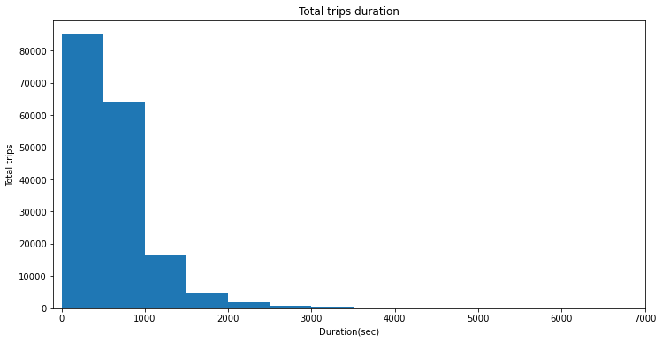

```python
#starting with a standard-scaled plot of duration
binsize = 500
bins = np.arange(0, trip_data['duration_sec'].max()+binsize, binsize)

plt.figure(figsize=[12, 6])
plt.hist(data = trip_data, x = 'duration_sec', bins = bins)
plt.title('Total trips duration')
plt.xlabel('Duration(sec)')
plt.ylabel('Total trips')
plt.xlim([-100,7000])
plt.show()
```

> From the plot there is a long tail in the distribution so lets try with a log scale.

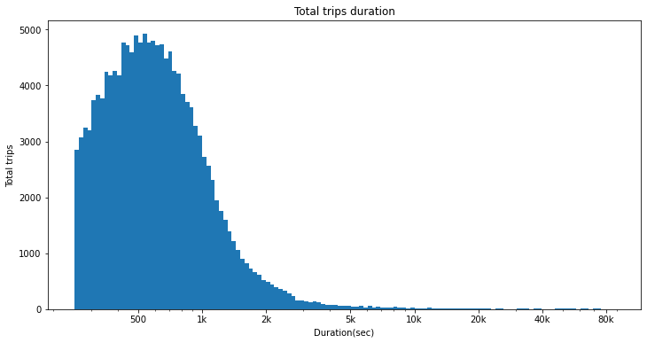

```python
# plotting on a log scale instead
log_binsize = 0.02
bins = 10 ** np.arange(2.4, np.log10(trip_data['duration_sec'].max())+log_binsize, log_binsize)

plt.figure(figsize=[12, 6])
plt.hist(data = trip_data, x = 'duration_sec', bins = bins)
plt.xscale('log')
plt.xticks([500, 1e3, 2e3, 5e3, 1e4, 2e4, 4e4, 8e4], [500, '1k', '2k', '5k', '10k', '20k', '40k', '80k'])
plt.title('Total trips duration')
plt.xlabel('Duration(sec)')
plt.ylabel('Total trips')
plt.show()
```

### Observation

> Duration has a long-tailed distribution, with most trips having durations on the low end, and few on the high end. When plotted on a log-scale, the duration distribution is unimodal and is slightly skewed right. The duration started at 200 with trips around 3000,with the peak between 500 and 700, then it falls gradually.

Lets look at the age feature

### What is the age range of most riders?

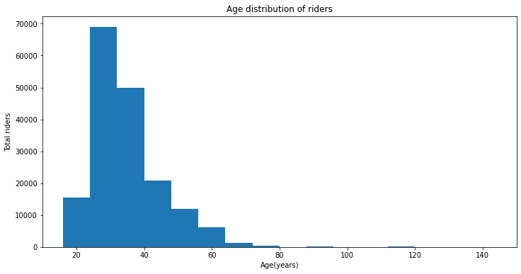

```python
#plotting the age distribution
binsize = 8
bins = np.arange(0, trip_data['age'].max()+binsize, binsize)
plt.figure(figsize=[12, 6])
plt.hist(data = trip_data, x = 'age', bins = bins)
plt.title('Age distribution of riders')
plt.xlabel('Age(years)')
plt.ylabel('Total riders')
plt.xlim([10,150])
plt.show()
```

### Observation

> The most bike riders have ages within 20 and 40, with the peak of the distribution at their 30's. From the plot most riders are in their youth while the elderlys ride less. Lets look at the member gender feature.

### What is the gender of most riders?

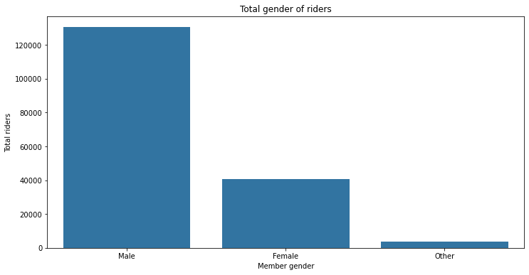

```python
#plotting the member gender
fig, ax = plt.subplots(figsize = [12,6])
default_color = sb.color_palette()[0]
sb.countplot(data = trip_data, x = 'member_gender', color = default_color, order= trip_data['member_gender'].value_counts().index)
plt.title('Total gender of riders')
plt.xlabel('Member gender')
plt.ylabel('Total riders')
plt.show()
```

### Observation

> Most of the bike riders are males, compared to the other genders the difference is much.

### The majority of users are of what type?

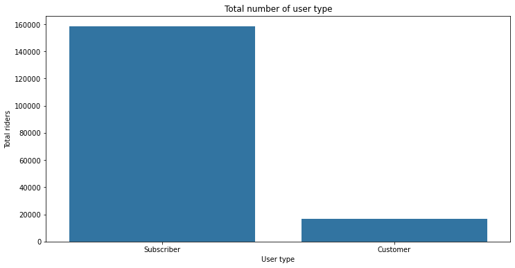

```python
#plotting the user type
fig, ax = plt.subplots(figsize = [12,6])
default_color = sb.color_palette()[0]
sb.countplot(data = trip_data, x = 'user_type', color = default_color, order= trip_data['user_type'].value_counts().index)
plt.title('Total number of user type')
plt.xlabel('User type')
plt.ylabel('Total riders')
plt.show()
```

#### Observation

> Most of the bikers are subscribers while a few are customers.

### What day had the most bike rides?

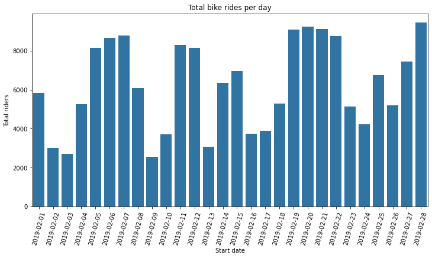

```python
#plotting start date
fig, ax = plt.subplots(figsize = [12,6])
default_color = sb.color_palette()[0]
sb.countplot(data = trip_data.sort_values(by = ['start_date']), x = 'start_date', color = default_color)
plt.title('Total bike rides per day')
plt.xlabel('Start date')
plt.ylabel('Total riders')
plt.xticks(rotation=75)
plt.show()
```

### Observation

> Most people came for a bike ride at the end of the month, which is the 28th day of February.

### What weekday do most people ride bike?

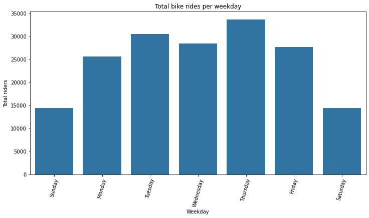

```python
#plotting the weekday
weekday = ['Sunday', 'Monday', 'Tuesday', 'Wednesday', 'Thursday', 'Friday', 'Saturday']
fig, ax = plt.subplots(figsize = [12,6])
default_color = sb.color_palette()[0]
sb.countplot(data = trip_data, x = 'start_weekday', color = default_color, order= weekday)
plt.title('Total bike rides per weekday')
plt.xlabel('Weekday')
plt.ylabel('Total riders')
plt.xticks(rotation=75)
plt.show()
```

### Observation

> Most people go for a bike ride on Thursdays, while few people go on weekends i.e Saturdays and Sundays.

### Do most bikers share a bike?

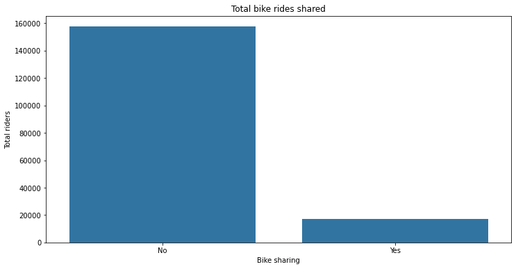

```python
#plotting the bike share
fig, ax = plt.subplots(figsize = [12,6])
default_color = sb.color_palette()[0]
sb.countplot(data = trip_data, x = 'bike_share_for_all_trip', color = default_color)
plt.title('Total bike rides shared')
plt.xlabel('Bike sharing')
plt.ylabel('Total riders')
plt.show()
```

### Observation

> Most people do not share their bikes, they go on rides alone.

### Discuss the distribution(s) of your variable(s) of interest. Were there any unusual points? Did you need to perform any transformations?

> The trip duration took on a large range of values, so I looked at the data using a log transform. Under the transformation, the data looked unimodal, with the peak between 500 and 700, and the plot was slightly skewed right.

### Of the features you investigated, were there any unusual distributions? Did you perform any operations on the data to tidy, adjust, or change the form of the data? If so, why did you do this?

> After cleaning the data extra features were extrated from the given features, to enhance our exploration on the dataset from more angles.

## Bivariate Exploration

> In this section, investigation of relationships between pairs of variables in the dataset is carried out.

### Does age affect the trip duration?

```
correlation : 0.0060411748752546846
```

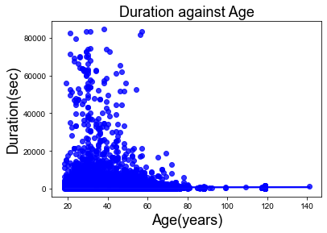

```python
#plotting duration against age
ax=sb.regplot(x= trip_data['age'], y= trip_data['duration_sec'], color='blue')
ax.set_title('Duration against Age', fontsize = 18)
ax.set_xlabel('Age(years)', fontsize=18)
ax.set_ylabel('Duration(sec)', fontsize=18)
sb.set(rc={'figure.figsize':(12,6)})
correlation = trip_data.corr()
print ('correlation :', correlation.loc['duration_sec','age'] )
```

### Observation

> From the plot, duration had no correlation with age, but younger riders tend to stay longer on trips than the elderly riders.

### Which gender spend longer time on trips?

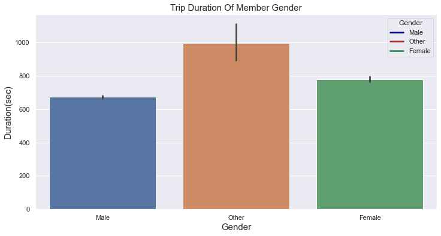

```python
#plotting a bar plot of duration and gender
ax=sb.barplot(x='member_gender', y='duration_sec', data=trip_data)
plt.xlabel('Gender', fontsize=15)
plt.ylabel('Duration(sec)', fontsize=15)
plt.title('Trip Duration Of Member Gender', fontsize=15)
plt.figure(figsize=(12,6))
leg=ax.legend(['Male', 'Other', 'Female'], title='Gender')
leg.legendHandles[0].set_color('darkblue')
leg.legendHandles[1].set_color('brown')
leg.legendHandles[2].set_color('seagreen')
plt.show()
```

### Observation

> The Other gender take longer trips than the female and male, the male gender spend less time on trips.

### Which user type take long trips?

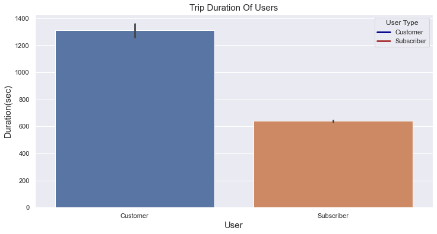

```python
#plotting a bar plot of duration and user type
plt.figure(figsize=(12,6))
ax=sb.barplot(x='user_type', y='duration_sec', data=trip_data)
plt.xlabel('User', fontsize=15)
plt.ylabel('Duration(sec)', fontsize=15)
plt.title('Trip Duration Of Users', fontsize=15)
leg=ax.legend(['Customer', 'Subscriber'], title='User Type')
leg.legendHandles[0].set_color('darkblue')
leg.legendHandles[1].set_color('brown')
plt.show()
```

### Observation

> Customers take trips twice as long as subscribers do.

### What day did bikers ride the longest?

| start_date | duration_sec |
| --- | --- |
| 2019-02-13 | 591.198830 |
| 2019-02-26 | 607.240331 |
| 2019-02-25 | 632.103892 |
| 2019-02-04 | 639.817372 |
| 2019-02-05 | 644.657817 |
| 2019-02-08 | 650.375615 |
| 2019-02-06 | 652.865280 |
| 2019-02-12 | 656.124831 |
| 2019-02-07 | 657.515003 |
| 2019-02-01 | 666.134031 |
| 2019-02-21 | 670.862390 |
| 2019-02-14 | 674.273558 |
| 2019-02-27 | 677.070095 |
| 2019-02-19 | 683.265172 |
| 2019-02-20 | 691.599286 |
| 2019-02-22 | 693.611865 |
| 2019-02-15 | 705.409488 |
| 2019-02-28 | 707.502329 |
| 2019-02-03 | 708.041344 |
| 2019-02-11 | 712.878773 |
| 2019-02-02 | 736.701299 |
| 2019-02-18 | 811.661820 |
| 2019-02-24 | 821.026957 |
| 2019-02-16 | 827.830209 |
| 2019-02-09 | 857.184386 |
| 2019-02-10 | 910.723289 |
| 2019-02-23 | 928.279056 |
| 2019-02-17 | 955.357493 |

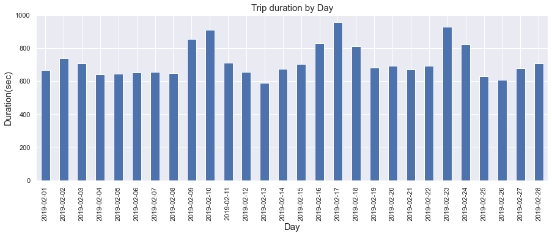

```python
#plotting bar plot of duration and date
date_du= trip_data.groupby('start_date')['duration_sec'].mean()
date_du.plot(kind='bar',figsize =(15,5))
plt.xlabel('Day', fontsize=15)
plt.ylabel('Duration(sec)', fontsize=15)
plt.title('Trip duration by Day', fontsize=15)
pd.DataFrame(trip_data.groupby('start_date')['duration_sec'].mean().sort_values(ascending=True))
```

### Observation

On the 17th of February, bikers spent the longest time on their trip.

### What day of the week do most people ride the longest?

| start_weekday | duration_sec |
| --- | --- |
| Tuesday | 652.839459 |
| Wednesday | 665.127946 |
| Thursday | 678.289748 |
| Friday | 681.274699 |
| Monday | 696.970906 |
| Saturday | 849.771750 |
| Sunday | 858.673649 |

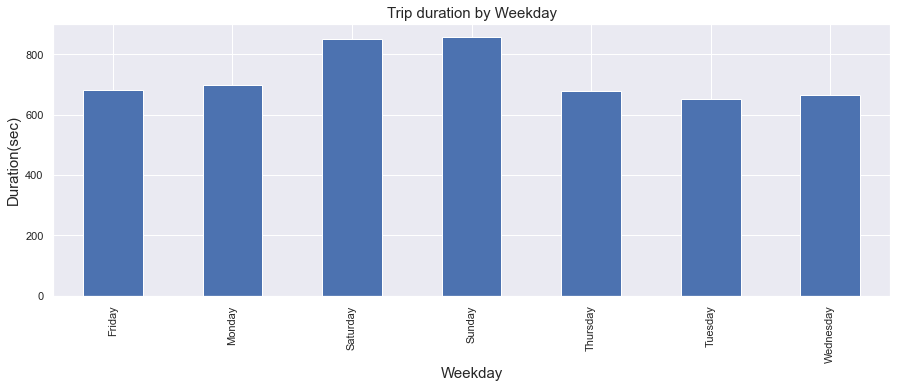

```python
#plotting weekday and duration
day_du= trip_data.groupby('start_weekday')['duration_sec'].mean()
day_du.plot(kind='bar',figsize =(15,5))
plt.xlabel('Weekday', fontsize=15)
plt.ylabel('Duration(sec)', fontsize=15)
plt.title('Trip duration by Weekday', fontsize=15)
pd.DataFrame(trip_data.groupby('start_weekday')['duration_sec'].mean().sort_values(ascending=True))
```

### Observation

> Most people ride longer on weekends i.e Saturday and Sunday, while they spend longer on Sundays.

### Did you observe any interesting relationships between the other features (not the main feature(s) of interest)?

> Most bikers do not stay long during the beginning of the month compared to the rest days of the month, with the peak at the middle of the month. People tend to take longer trips on weekends than weekdays.

## Multivariate Exploration

> Plots of three or more variables are investigated to take the data exploration even further.

### Which user type go on longer trips?

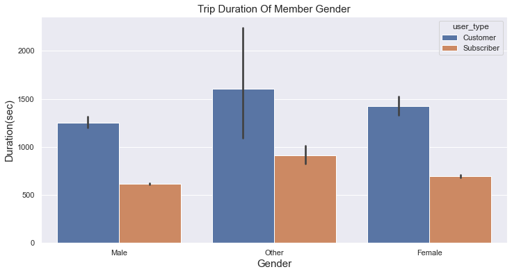

```python
#plotting gender, duration and user type
sb.barplot(x='member_gender', y='duration_sec', hue='user_type', data=trip_data)
plt.xlabel('Gender', fontsize=15)
plt.ylabel('Duration(sec)', fontsize=15)
plt.title('Trip Duration Of Member Gender', fontsize=15)
plt.figure(figsize=(12,6))
plt.show()
```

### Observation

> The customers go on longer trips among all the genders, and the Other customers go the longest.

### Whats the trip duration like among members of different ages?

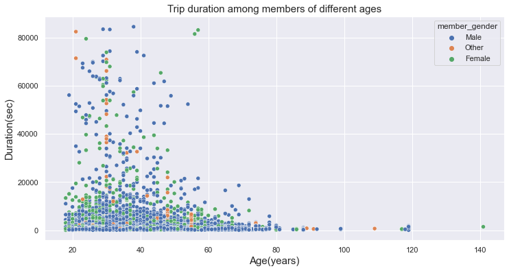

```python
#plotting duration, age and gender
fig, ax = plt.subplots(figsize=[12,6])
ax = sb.scatterplot(data= trip_data, x=trip_data['age'], y=trip_data['duration_sec'], hue='member_gender')
plt.xlabel('Age(years)', fontsize=15)
plt.ylabel('Duration(sec)', fontsize=15)
plt.title('Trip duration among members of different ages', fontsize=15)
plt.show()
```

### Observation

> As expected the males are more dominant compared to the other gender, and the younger bikers tend to stay longer on trips.

### Whats the trip duration like among user types of different ages?

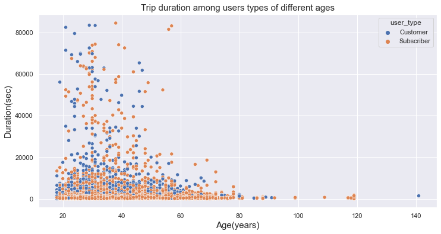

```python
#plotting duration, age and user type
fig, ax = plt.subplots(figsize=[12,6])
ax = sb.scatterplot(data= trip_data, x=trip_data['age'], y=trip_data['duration_sec'], hue='user_type')
plt.xlabel('Age(years)', fontsize=15)
plt.ylabel('Duration(sec)', fontsize=15)
plt.title('Trip duration among users types of different ages', fontsize=15)
plt.show()
```

### Observation

> The younger customers stay longer on trips than the older ones, and the subscribers are dominant on the plot.

### Talk about some of the relationships you observed in this part of the investigation. Were there features that strengthened each other in terms of looking at your feature(s) of interest?

> The customers really stay the longest amongs all the gender, and the Other gender stayed longer, even when the male gender is dominant.

### Were there any interesting or surprising interactions between features?

> Although the subscribers are dominant, the customers stay longer on trips

## Conclusions

The dataset did not have any duplicates but null values were present. After cleaning, extra features were extrated from the data to assist in the exploration and the following findings were derived at;

1. Most people who go for rides are within the age range of 20-40 years.
2. The male gender is more dominant in the bike trips.
3. Most users are subcribers.
4. Although subscribers are more, customers tend to go on longer trips.
5. Most people go on bike rides on thursday, but they tend to stay longer on weekends.

## References

- Udacity lecture materials
- Stack overflow